# Storytelling visual con R. Lab 2 con Starwars ⚔

Curso formativo para el PDI. Universidad de Castilla-La Mancha

Autores/as

Gema Fernández-Avilés

Isidro Hidalgo

Fecha de publicación

10 de marzo de 2025

**IMPORTANTE**

📕 **Como buen estudiante que eres, sabrás lo importante que es trabajar de forma autónoma y venir a clase con el material leído 😊**.

🦄 Este icono indica **AVANZADO E IMPORTANTE**

**Paso (i):** Lectura de paquetes

```r
library(ggplot2)    # Visualización de datos
library(dplyr)      # Manipulación de datos
library(ggpmisc)    # Añade la linea de regresión en el plot
```

**Paso (ii):** Lectura y visualización de los datos

```r
head(starwars)
```

```
# A tibble: 6 × 14
  name      height  mass hair_color skin_color eye_color birth_year sex   gender
  <chr>      <int> <dbl> <chr>      <chr>      <chr>          <dbl> <chr> <chr>
1 Luke Sky…    172    77 blond      fair       blue            19   male  mascu…
2 C-3PO        167    75 <NA>       gold       yellow         112   none  mascu…
3 R2-D2         96    32 <NA>       white, bl… red             33   none  mascu…
4 Darth Va…    202   136 none       white      yellow          41.9 male  mascu…
5 Leia Org…    150    49 brown      light      brown           19   fema… femin…
6 Owen Lars    178   120 brown, gr… light      blue            52   male  mascu…
# ℹ 5 more variables: homeworld <chr>, species <chr>, films <list>,
#   vehicles <list>, starships <list>
```

**Paso (iii)** Punto de partida

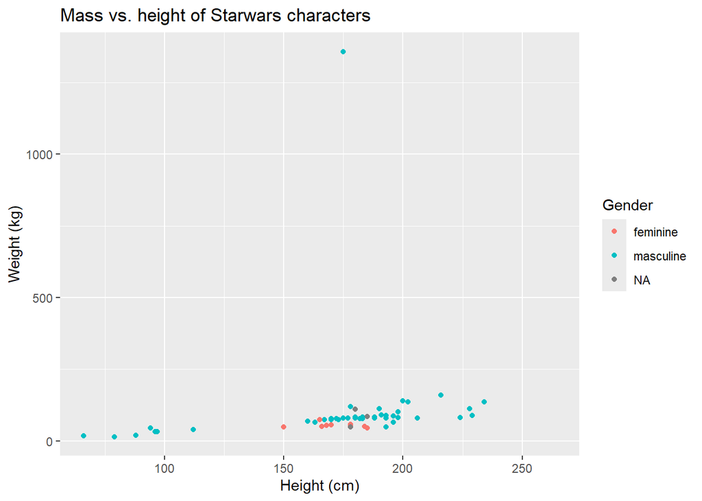

```r
ggplot(data = starwars,
       mapping = aes(x = height,
                     y = mass,
                     colour = gender)) +
  geom_point() +
  labs(title = "Mass vs. height of Starwars characters",
       x = "Height (cm)",
       y = "Weight (kg)",
       colour = "Gender")
```

**Tu turno**

## 0.1 Tu turno

Completa las partes del código señaladas por `_____` o `xxxxx` para obtener el resultado deseado y acuérdate de cambiar `eval: false` por `eval: true` cuando lo hayas cumplimentado para que se ejecute correctamente la chunk.

# 1 Unidad 4. 😔 El desorden es tu enemigo

Para evitar el desorden, podemos simplificar la visualización eliminando elementos innecesarios y enfocándonos en lo esencial. ¿Son necesarios los `NA` en este caso? ¿El fondo gris aporta información?

**Paso 1** Elimino los datos faltantes, NA (Not Avaliable) con la función `is.na()`, indicando que filtre los que son distintos a NA (con el operador `!`). Guardo el nuevo conjunot de datos en el objeto `starwars_clean`.

```r
starwars_clean <- starwars |>
  filter(!is.na(gender))
```

**Paso 2** Compruebo que no tengo `NAs` con la función `is.na()`.

```r
summary(is.na(starwars_clean))
```

```
    name           height           mass         hair_color
 Mode :logical   Mode :logical   Mode :logical   Mode :logical
 FALSE:83        FALSE:77        FALSE:56        FALSE:78
                 TRUE :6         TRUE :27        TRUE :5
 skin_color      eye_color       birth_year         sex
 Mode :logical   Mode :logical   Mode :logical   Mode :logical
 FALSE:83        FALSE:83        FALSE:43        FALSE:83
                                 TRUE :40
   gender        homeworld        species          films
 Mode :logical   Mode :logical   Mode :logical   Mode :logical
 FALSE:83        FALSE:73        FALSE:83        FALSE:83
                 TRUE :10
  vehicles       starships
 Mode :logical   Mode :logical
 FALSE:83        FALSE:83
```

**Paso 3** Cambio el tema del fondo del gráfico. Prueba algunos y elige el que consideres más apropiado: `theme_bw()`, `theme_minimal()`, `theme_light()`, `theme_dark()`,…

```r
ggplot(data = starwars_clean,
       mapping = aes(x = height,
                     y = mass,
                     colour = gender)) +
  geom_point() +
  labs(title = "Mass vs. Height of Starwars Characters",
       x = "Height (cm)", y = "Weight (kg)",
       colour = "Gender") +
  theme_xxx()
```

# 2 Unidad 5. 🛑 Centra la atención de tu audiencia

Para centrar la atención, podemos analizar ciertos puntos de interés, como los personajes con alturas y pesos extremos.

**Paso 1** Centro la atención en el personaje *outlier* para ver quién es. Para ello filtro (`filter()`) los valores de la variable `mass > 1000` e indico que ponga una etiqueta con la variable `label = name` .

```r
ggplot(starwars_clean |>
         filter(_____ > ____),
       aes(x = ___,
           y = ___,
           label = ____,
           colour = ____)) +
  geom_point() +
  geom_text(hjust = 1.1, vjust = 1.1, size = 3) +
  labs(title = "Characters with Mass Greater than 1000",
       x = "Height (cm)",
       y = "Weight (kg)",
       colour = "Gender") +
  theme_bw()
```

**Paso 2** Determinamos el conjunto de datos objetivo. En este caso, eliminamos el personaje *outlier*, `Jabba Desilijic Tiure`, del conjunto de datos `starwars_clean` y lo guardamos en el objeto `starwars_clean_sin_outlier`.

```r
starwars_clean_sin_outlier <- starwars_clean |>
      filter(name != "Jabba Desilijic Tiure")
```

**Paso 3** Representamos el diagrama de dispersión del conjunto de datos `starwars_clean_sin_outlier`.

```r
ggplot(starwars_clean_sin_outlier,
       mapping = aes(x = height,
                     y = mass,
                     colour = gender)) +
  geom_point() +
  labs(title = "Mass vs. Height of Starwars Characters (Excluding Jabba)",
       x = "Height (cm)", y = "Weight (kg)",
       colour = "Gender") +
    theme_bw()
```

# 3 Unidad 6. 🎨 Piensa como un diseñador

Para pensar como un diseñador, podemos usar colores y formas que hagan la visualización más atractiva y fácil de entender.

**Paso 1** Añade colores y formas al gráfico, además de la fuente de los datos.

```r
ggplot(starwars_clean_sin_outlier,
       mapping = aes(x = height,
                     y = mass,
                     colour = gender,
                     ______ = gender)) +
  geom_point(size = 3) +
  labs(title = "Mass vs. Height of Starwars Characters",
       x = "Height (cm)",
       y = "Weight (kg)",
       colour = "Gender",
       ______ = "Gender",
       caption = "Source: dplyr package") +
  theme_minimal() +
  scale_colour_viridis_d() +
  theme(legend.position = "bottom")
```

# 4 Unidad 7. 📖 Cuenta una historia

Para contar una historia, podemos agregar anotaciones que expliquen los datos y guíen al espectador a través de la visualización.

**Paso 1** Destaca los personajes más importantes y cambia la escala de color.

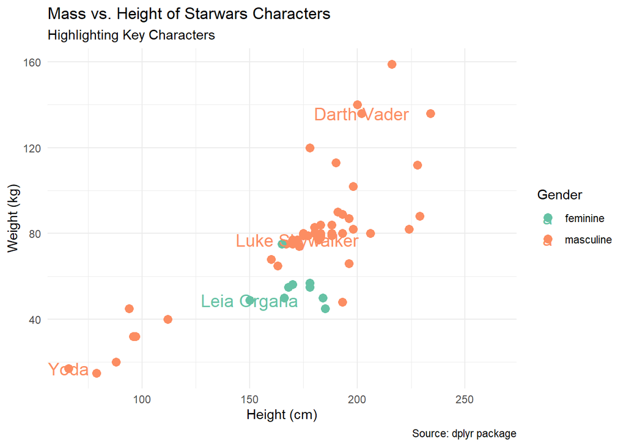

```r
ggplot(starwars_clean_sin_outlier,
       mapping = aes(x = height,
                     y = mass,
                     colour = gender)) +
  geom_point(size = 3) +
  geom_text(aes(label = ifelse(name %in% c("Darth Vader", "Luke Skywalker", "Leia Organa", "Yoda"),
                               name, " ")),
            size = 5) +
  labs(title = "Mass vs. Height of Starwars Characters",
       subtitle = "Highlighting Key Characters",
       x = "Height (cm)", y = "Weight (kg)",
       colour = "Gender",
       caption = "Source: dplyr package") +
  theme_minimal() +
scale_colour_brewer(palette = "Set2")
```

**Paso 2** Añade una linea de regresión con sus coeficientes y el R2.

[figure not shown]

```r
ggplot(starwars_clean_sin_outlier,
       mapping = aes(x = height,
                     y = mass,
                     colour = gender)) +
  geom_point(size = 3) +
  geom_smooth(method = "lm", se = FALSE, aes(colour = gender)) +  # Línea de regresión por género
  stat_poly_eq(aes(label = paste(..eq.label.., ..rr.label.., sep = "~~~"),
                   colour = gender),
               formula = y ~ x,
               parse = TRUE, label.x.npc = "right", label.y.npc = "top") +
  labs(title = "Mass vs. Height of Starwars Characters",
       x = "Height (cm)", y = "Weight (kg)",
       colour = "Gender",
       caption = "Source: dplyr package") +
  theme_minimal() +
  scale_colour_brewer(palette = "Set2") +
  theme(legend.position = "bottom")
```

[figure not shown]